# Coursera Practical Machine Learning Course - Prediction Assignment

Mathew Erzoah

March 30, 2021

## Introduction

Using devices such as Jawbone Up, Nike FuelBand, and Fitbit it is now possible to collect a large amount of data about personal activity relatively inexpensively. These type of devices are part of the quantified self movement – a group of enthusiasts who take measurements about themselves regularly to improve their health, to find patterns in their behavior, or because they are tech geeks. One thing that people regularly do is quantify how much of a particular activity they do, but they rarely quantify how well they do it. In this project, your goal will be to use data from accelerometers on the belt, forearm, arm, and dumbell of 6 participants. They were asked to perform barbell lifts correctly and incorrectly in 5 different ways. More information is available from the website here:[More info](http://web.archive.org/web/20161224072740/http:/groupware.les.inf.puc-rio.br/har)(see the section on the Weight Lifting Exercise Dataset).

### Weight Lifting Exercise Dataset

The training data for this project are available here:

[Training data](https://d396qusza40orc.cloudfront.net/predmachlearn/pml-training.csv)

The test data are available here:

[Test data](https://d396qusza40orc.cloudfront.net/predmachlearn/pml-testing.csv)

The data for this project come from this source: [here](http://web.archive.org/web/20161224072740/http:/groupware.les.inf.puc-rio.br/har). If you use the document you create for this class for any purpose please cite them as they have been very generous in allowing their data to be used for this kind of assignment.

The classe variable contains 5 different ways barbell lifts were performed correctly and incorrectly:

. Class A: exactly according to the specification . Class B: throwing the elbows to the front . Class C: lifting the dumbbell only halfway . Class D: lowering the dumbbell only halfway . Class E: throwing the hips to the front

## Objective

The goal of this project is to predict the manner in which people performed barbell lifts. This is the classe variable in the training set. You may use any of the other variables to predict with. You should create a report describing how you built your model, how you used cross validation, what you think the expected out of sample error is, and why you made the choices you did. You will also use your prediction model to predict 20 different test cases.

Packages for the analysis

```r
library(knitr)
library(caret)
library(randomForest)
```

```r
library(rpart)
library(rpart.plot)
library(RColorBrewer)
library(rattle)
library(corrplot)
library(e1071)
library(gbm)
set.seed(123)
```

Load data into R

```r
# The location where the training data is to be downloaded from
train_url <- "https://d396qusza40orc.cloudfront.net/predmachlearn/pml-training.csv"
# The location where the testing data is to be downloaded from
test_url <- "https://d396qusza40orc.cloudfront.net/predmachlearn/pml-testing.csv"

#Before downloading the data, you can change your working directory by setting the path in setwd()
# Download the training data in your working directory, if it hasn't been already
if (!file.exists("pml-training.csv")){
  download.file(train_url, destfile="pml-training.csv", method="curl")
}
# Read the Training CSV file into R & replace missing values & excel division error strings #DIV/0! with 'NA'

training<- read.csv("./pml-training.csv", na.strings=c("NA","#DIV/0!",""))


## Download the testing data in your working directory
if (!file.exists("pml-testing.csv")){
download.file(test_url, destfile="pml-testing.csv", method="curl")
}

# Read the Testing CSV file into R & replace missing values & excel division error strings #DIV/0! with 'NA'

testing <- read.csv("./pml-testing.csv", na.strings=c("NA","#DIV/0!",""))
dim(training)
```

```
## [1] 19622   160
```

```r
# Take a look at the Training data classe variable
summary(training$classe)
```

```
##    Length     Class      Mode
##     19622 character character
```

## Partitioning the data for cross-validation

The training data is split into two data sets, one for training the model and one for testing the performance of our model. The data is partitioned by the classe variable, which is the varible we will be predicting. The data is split into 60% for training and 40% for testing.

```r
inTrain <- createDataPartition(training$classe, p = 0.60, list = FALSE)
df.train <- training[inTrain,]
df.test <- training[-inTrain,]

dim(df.train); dim(df.test)
```

```
## [1] 11776   160
```

```
## [1] 7846  160
```

## Data Processing

Remove columns that contain NAs.

```r
df.train <- df.train[, colSums(is.na(df.train)) == 0]
df.test <- df.test[, colSums(is.na(df.test)) == 0]
```

Remove the Near Zero Variance columns

```r
NZV <- nearZeroVar(df.train)
df.train <- df.train[,-NZV]
df.test <- df.test[,-NZV]
```

Remove ID columns

```r
df.train <- df.train[,-(1:5)]
df.test <- df.test[,-(1:5)]
```

# check dimension

```r
dim(df.train)
```

```
## [1] 11776    54
```

```r
dim(df.test)
```

```
## [1] 7846   54
```

### Prediction model building

There are 54 variables left for analysis after the data processing. Three methods will be applied to model the regressions using the Train dataset and the best one with higher accuracy when applied to the Test dataset will be used for the quiz predictions. The methods are: Random Forests, Decision Tree and Generalized Boosted Model. A Confusion Matrix is plotted at the end of each analysis to better visualize the accuracy of the models.

### Method 1: Random Forest

First of all, we will build a Random Forest model and perform a prediction.

```r
set.seed(123)
mod.rf <- train(classe ~., data = df.train, method = "rf",
                trControl = trainControl("cv", number = 5))
mod.rf$finalModel
```

```
##
## Call:
##  randomForest(x = x, y = y, mtry = param$mtry)
##                Type of random forest: classification
##                      Number of trees: 500
## No. of variables tried at each split: 27
##
##         OOB estimate of  error rate: 0.25%
## Confusion matrix:
##      A    B    C    D    E  class.error
## A 3348    0    0    0    0 0.0000000000
## B    9 2268    2    0    0 0.0048266784
## C    0    4 2050    0    0 0.0019474197
## D    0    0   12 1918    0 0.0062176166
## E    0    0    0    2 2163 0.0009237875
```

#### Prediction with Random Forest Model

```r
pred.rf <- predict(mod.rf, df.test)
result.rf <- confusionMatrix(pred.rf, as.factor(df.test$classe))
result.rf
```

```
## Confusion Matrix and Statistics
##
##           Reference
## Prediction    A    B    C    D    E
##          A 2231    3    0    0    0
##          B    0 1512    4    0    0
##          C    0    2 1364    2    0
##          D    0    1    0 1283    2
##          E    1    0    0    1 1440
##
## Overall Statistics
##
##                Accuracy : 0.998
##                  95% CI : (0.9967, 0.9988)
##     No Information Rate : 0.2845
##     P-Value [Acc > NIR] : < 2.2e-16
##
##                   Kappa : 0.9974
##
##  Mcnemar's Test P-Value : NA
##
## Statistics by Class:
##
##                      Class: A Class: B Class: C Class: D Class: E
## Sensitivity            0.9996   0.9960   0.9971   0.9977   0.9986
## Specificity            0.9995   0.9994   0.9994   0.9995   0.9997
## Pos Pred Value         0.9987   0.9974   0.9971   0.9977   0.9986
## Neg Pred Value         0.9998   0.9991   0.9994   0.9995   0.9997
## Prevalence             0.2845   0.1935   0.1744   0.1639   0.1838
## Detection Rate         0.2843   0.1927   0.1738   0.1635   0.1835
## Detection Prevalence   0.2847   0.1932   0.1744   0.1639   0.1838
## Balanced Accuracy      0.9995   0.9977   0.9982   0.9986   0.9992
```

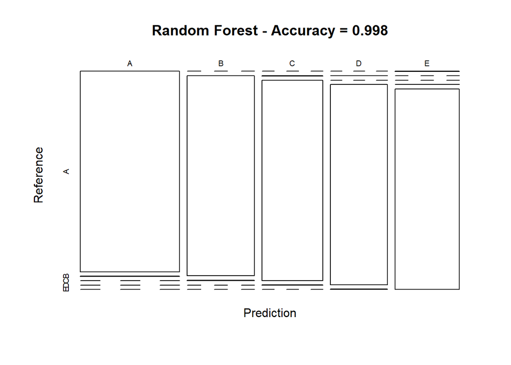

```r
# plot matrix results
plot(result.rf$table, col = result.rf$byClass,
     main = paste("Random Forest - Accuracy =",
                  round(result.rf$overall['Accuracy'], 4)))
```

### Method 2: Generalized Boosted Model (GBM)

```r
set.seed(123)
mod.gbm <- train(classe ~., data = df.train,
                 method = "gbm", verbose = FALSE,
                 trControl = trainControl(method = "cv", number = 5))
mod.gbm
```

```
## Stochastic Gradient Boosting
##
## 11776 samples
##    53 predictor
##     5 classes: 'A', 'B', 'C', 'D', 'E'
##
## No pre-processing
## Resampling: Cross-Validated (5 fold)
## Summary of sample sizes: 9420, 9421, 9420, 9421, 9422
## Resampling results across tuning parameters:
##
##   interaction.depth  n.trees  Accuracy   Kappa
##   1                   50      0.7572160  0.6919090
##   1                  100      0.8325396  0.7880080
##   1                  150      0.8694789  0.8348284
##   2                   50      0.8828099  0.8516050
##   2                  100      0.9369047  0.9201733
##   2                  150      0.9617859  0.9516436
##   3                   50      0.9290921  0.9102227
##   3                  100      0.9700235  0.9620708
##   3                  150      0.9864979  0.9829213
##
## Tuning parameter 'shrinkage' was held constant at a value of 0.1
##
## Tuning parameter 'n.minobsinnode' was held constant at a value of 10
## Accuracy was used to select the optimal model using the largest value.
## The final values used for the model were n.trees = 150, interaction.depth =
##  3, shrinkage = 0.1 and n.minobsinnode = 10.
```

#### Prediction with Generalized Boosted Model

```r
pred.gbm <- predict(mod.gbm, df.test)
result.gbm <- confusionMatrix(pred.gbm,
                              as.factor(df.test$classe))
```

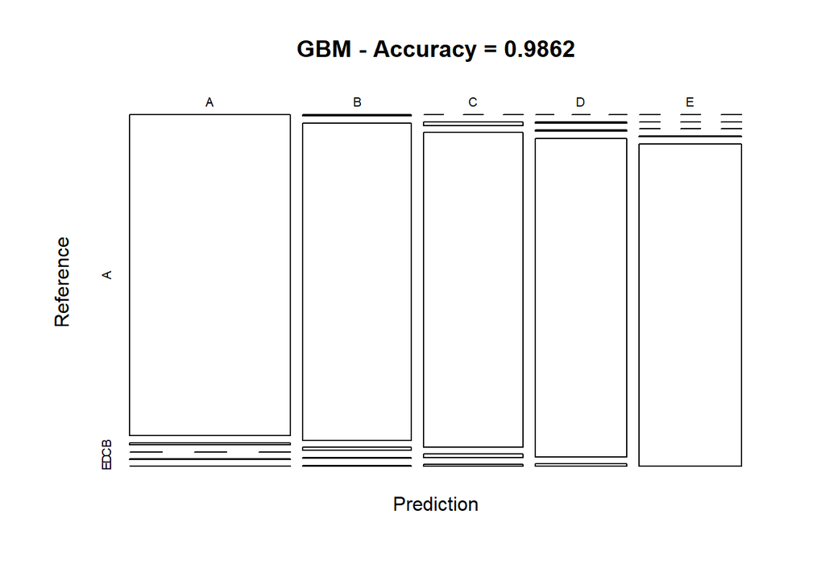

```r
# plot matrix results
plot(result.gbm $table, col = result.gbm $byClass,
     main = paste("GBM - Accuracy =",
                  round(result.gbm $overall['Accuracy'], 4)))
```

### Method 3: Decision Trees

```r
set.seed(123)
mod.rpart <- train(classe ~., data = df.train, method = "rpart")
mod.rpart
```

```
## CART
##
## 11776 samples
##    53 predictor
##     5 classes: 'A', 'B', 'C', 'D', 'E'
##
## No pre-processing
## Resampling: Bootstrapped (25 reps)
## Summary of sample sizes: 11776, 11776, 11776, 11776, 11776, 11776, ...
## Resampling results across tuning parameters:
##
##   cp          Accuracy   Kappa
##   0.02467964  0.6239133  0.5223559
##   0.04382218  0.4921364  0.3313510
##   0.11212625  0.3308585  0.0710121
##
## Accuracy was used to select the optimal model using the largest value.
## The final value used for the model was cp = 0.02467964.
```

#### Prediction with Decision Tree model

```r
pred.rpart <- predict(mod.rpart, df.test)
result.rpart <- confusionMatrix(pred.rpart, as.factor(df.test$classe))
```

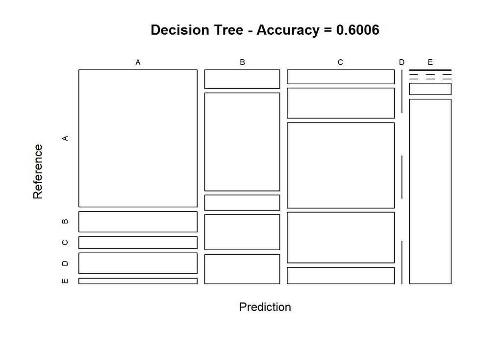

```r
# plot matrix results
plot(result.rpart$table, col = result.rpart$byClass,
     main = paste("Decision Tree - Accuracy =",
                  round(result.rpart$overall['Accuracy'], 4)))
```

## Prediction on the Test data

```r
pred.quiz <- predict(mod.rf, testing)
pred.quiz
```

```
##  [1] B A B A A E D B A A B C B A E E A B B B
## Levels: A B C D E
```

## Conclusion

There are many different machine learning algorithms. I chose to compare a number of them, and for this data, the Random Forest proved to be a more accurate way to predict the manner in which the exercise was done.